# website_versions_comparisons

```python
import pandas as pd
import numpy as np
from pandas_profiling import ProfileReport
import matplotlib.pyplot as plt
import seaborn as sns

from scipy import stats
from termcolor import colored as cl
```

```python
task1 = pd.read_excel('Dataset_Task1_Solid_Data_Analyst.xlsx', na_values=['Nan', 'UNK'])
```

```python
# printing first 5 rows
task1.head()
```

|  | DEVICES_BRANDS | BROWSERS | DEVICE_TYPE | Conversion | A/B | config_os | config_os_version | config_resolution | idvisit | platform_v4 |
| --- | --- | --- | --- | --- | --- | --- | --- | --- | --- | --- |
| 0 | Other | CHROME MOBILE | SMARTPHONE | 1 | old | AND | 7 | 360x640 | 4801472 | MOB |
| 1 | Other | Other | NaN | 1 | old | AND | 4.3 | 1440x1440 | 4790389 | MOB |
| 2 | SAMSUNG | CHROME MOBILE | SMARTPHONE | 1 | new | AND | 7 | 360x640 | 5272442 | MOB |
| 3 | APPLE | MOBILE SAFARI | SMARTPHONE | 1 | new | IOS | 11.3 | 414x736 | 5030185 | MOB |
| 4 | Other | CHROME MOBILE | SMARTPHONE | 1 | old | AND | 7 | 360x640 | 3857978 | MOB |

# Preparing data and doing feature engeneering

```python
# feature engeneering part
# compute total resolutions from config_resolution
dimentions = pd.DataFrame(task1['config_resolution'].str.split('x',1).tolist(), columns = ['w','l']).astype(float)
task1['resolution']=dimentions.w*dimentions.l

# create categories for resolutions (small, medium, large)
max_r = task1['resolution'].max()
min_r = task1['resolution'].min()
step = (max_r-min_r)/3

cat_of_res = []
for r in task1['resolution']:
    if r<min_r+step:
        cat_of_res.append('small')
    elif r<min_r+2*step:
        cat_of_res.append('medium')
    else:
        cat_of_res.append('large')

task1['resolution_cat'] = cat_of_res
```

```python
# data preporation part
# convert config_os_version to str
task1['config_os_version'] = task1['config_os_version'].astype(str)

#converting all column names to lowecase for easier reference later on
task1.columns=task1.columns.str.lower()
```

```python
task1.info()
```

```
<class 'pandas.core.frame.DataFrame'>
RangeIndex: 26585 entries, 0 to 26584
Data columns (total 12 columns):
 #   Column             Non-Null Count  Dtype
---  ------             --------------  -----
 0   devices_brands     26585 non-null  object
 1   browsers           26585 non-null  object
 2   device_type        26478 non-null  object
 3   conversion         26585 non-null  int64
 4   a/b                26585 non-null  object
 5   config_os          26551 non-null  object
 6   config_os_version  26585 non-null  object
 7   config_resolution  26585 non-null  object
 8   idvisit            26585 non-null  int64
 9   platform_v4        26585 non-null  object
 10  resolution         26585 non-null  float64
 11  resolution_cat     26585 non-null  object
dtypes: float64(1), int64(2), object(9)
memory usage: 2.4+ MB
```

# Exploratory analysis

```python
task1.profile_report()
```

[interactive chart not shown]

The most important notice from the above profile report: idvisit is perfecly correlated to a/b column according to Phik correlation. Check the plot below:

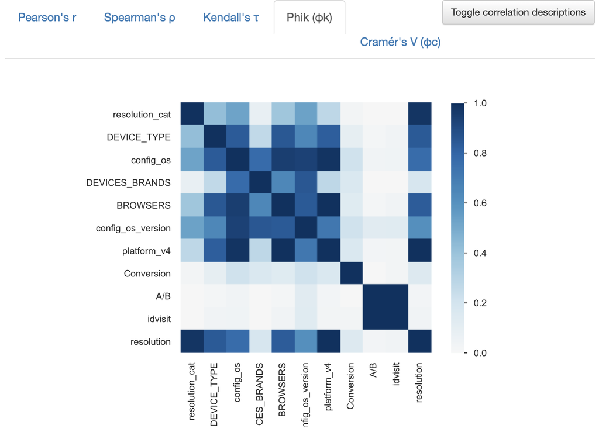

Lets understand better the relation between those 2 columns:

```python
#checking which idvisits were used for A/B testing
task1.groupby('a/b')['idvisit'].describe()
```

| a/b | count | mean | std | min | 25% | 50% | 75% | max |
| --- | --- | --- | --- | --- | --- | --- | --- | --- |
| new | 15429.0 | 5.506254e+06 | 397130.214852 | 4819232.0 | 5145865.00 | 5494389.0 | 5845565.00 | 6187249.0 |
| old | 11156.0 | 4.327764e+06 | 285298.874271 | 3843556.0 | 4083326.75 | 4324054.5 | 4569729.75 | 4818942.0 |

Notice that idvisits which experienced old version are in range (3843556, 4818942) and new version (4819232, 6187249). I assume that idvisit depends on the time of the visit and hence people that had old vesion were tested before new, i.e during different time period. It could affect our conversion rates because people tend to have different conversions during weekdays, weekends, holidays, part of the month and seasons.

# Conversion analysis

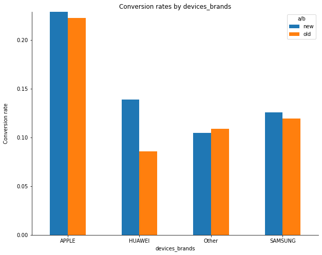

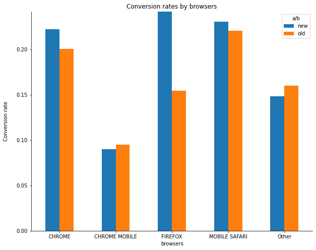

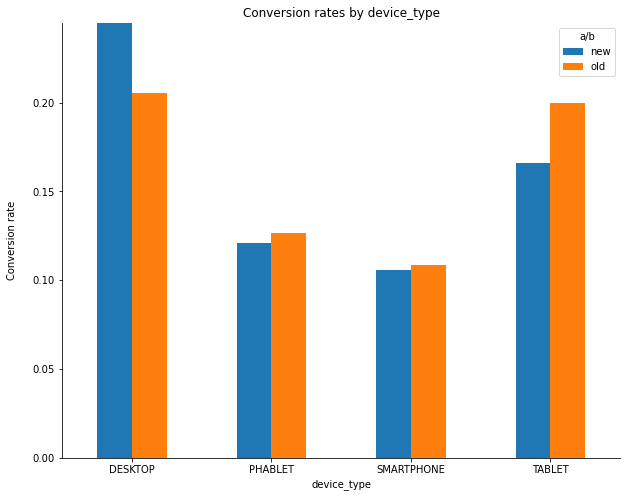

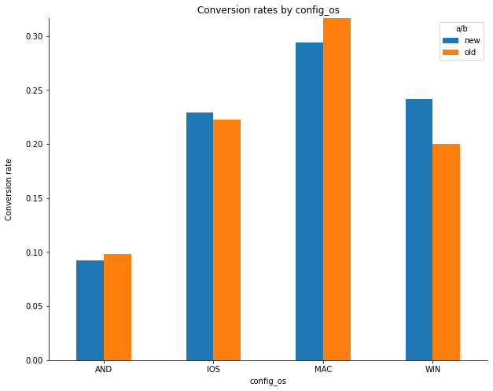

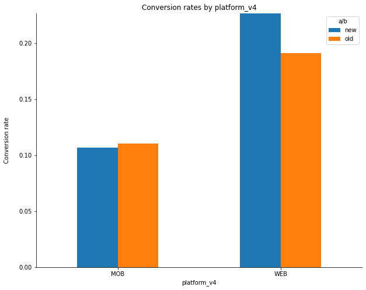

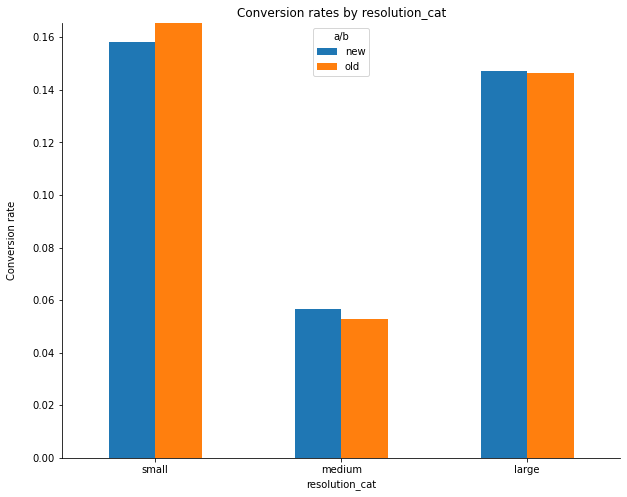

```python
#separating colums with categorical data
cat_columns=['devices_brands',
             'browsers',
             'device_type',
             'config_os',
             'platform_v4',
             'resolution_cat']

#printing conversions for cat_columns and different versions
for col in cat_columns:
    df = task1.groupby(['a/b',col])['conversion'].mean().unstack(level=0)

    #removing small sample groups that represent <0.5% from total population
    size = task1.groupby(col)['a/b'].count()
    df = df[size>len(task1)/200]


    ax = df.plot(kind='bar', figsize=(10,8))

    #setting-up graphs style
    plt.title('Conversion rates by {}'.format(col))
    plt.ylabel('Conversion rate\n')
    plt.ylim(0,df.values.max())
    plt.xlabel('{}'.format(col))
    plt.xticks(rotation=0)
    sns.despine()

    plt.show()
```

We can clearly notice a few important changes:

1. People that use HUAWEI, Firefox, Desktop, WEB (PC), WIN showed a better conversion in comparison to old version
2. People that use Tablet, MAC showed a worse conversion in comparison to old version

However, we need to be sure that these changes are not caused by a random change. We need to conduct hypothesis testing where:

Null hypothesis: there are no significant change and difference caused by a random chance Alternative hypothesis: there is a significant change and difference is not caused by a random chance

For this analysis we will calculate p-value for each category and if it <0.1 than H1 is valid and we reject Null hypothesis.

```python
# performing T-test to find p-values for each category
for col in cat_columns:
    for category in task1[col].unique():
        rv1=task1[(task1[col]==category)&(task1['a/b']=='old')]['conversion']
        rv2=task1[(task1[col]==category)&(task1['a/b']=='new')]['conversion']
        t_val, p_val = stats.ttest_ind(rv1,rv2, equal_var = False)
        print(cl('------------------------------------------------------------------------\n', attrs = ['bold']))
        print('T-test for {}:{}'.format(col,category))
        print('p-value: {}\n'.format(p_val))
```

```
------------------------------------------------------------------------

T-test for devices_brands:Other
p-value: 0.38574983879984537

------------------------------------------------------------------------

T-test for devices_brands:SAMSUNG
p-value: 0.5129666467097148

------------------------------------------------------------------------

T-test for devices_brands:APPLE
p-value: 0.702821560841308

------------------------------------------------------------------------

T-test for devices_brands:HUAWEI
p-value: 0.08529379427100599

------------------------------------------------------------------------

T-test for browsers:CHROME MOBILE
p-value: 0.23800373541808664

------------------------------------------------------------------------

T-test for browsers:Other
p-value: 0.658400424481244

------------------------------------------------------------------------

T-test for browsers:MOBILE SAFARI
p-value: 0.5585052624746112

------------------------------------------------------------------------

T-test for browsers:CHROME
p-value: 0.171113320743005

```

[output cut: 99 more lines]

```

------------------------------------------------------------------------

T-test for resolution_cat:small
p-value: 0.9016572395343332

------------------------------------------------------------------------

T-test for resolution_cat:medium
p-value: 0.5082851966436419

------------------------------------------------------------------------

T-test for resolution_cat:large
p-value: 0.8064600293118331
```

From calculated above p-values we notice that HUAWEI, FIREFOX, WEB, DESKTOP, WIN have statistically significant differences.

# Conclusion

New version of the website didnt lose in any category to the old version. Moreover, new version of the payment gateway should be shown to people that use:

1. Huawei products
2. Firefox browser
3. Web (not mobile)
4. Desktop
5. Windows